# Climate Water Loss Experiment - Plasma Osmolality Data Wrangling

Savannah Weaver

2021

# Packages

```r
`%nin%` = Negate(`%in%`)
if (!require("tidyverse")) install.packages("tidyverse")
```

```r
library("tidyverse") # workflow and plots
if (!require("rmdformats")) install.packages("rmdformats")
library("rmdformats") # clean html R markdown format
```

# Background and Goals

Blood was drawn from the postorbital sinus of adult male *Sceloporus occidentalis* between June - August 2021. After centrifuging and separating, plasma was run on a VAPRO vapor pressure osmometer in 1-4 replicates, when plasma volume allowed. In this R script, I check the distribution of replicates, omit outliers, and average remaining replicates. The final values will be more precise and accurate estimates of the true plasma osmolality for each lizard, and those values will be used in the capture_analysis and experiment_analysis R script files.

# Load Data

```r
osml_reps <- read.csv("./data/osmolality.csv",
                na.strings = c("","NA"),
                header = TRUE
                ) %>%
    dplyr::mutate(date_blood_drawn = as.Date(date_blood_drawn,
                                             format = "%m/%d/%y"),
                  date_osmom_run = as.Date(date_osmom_run,
                                           format = "%m/%d/%y"),
                  time_osmom_run = as.POSIXct(time_osmom_run,
                                               format = "%H:%M"),
                  individual_ID = as.factor(individual_ID),
                  replicate_no = as.factor(replicate_no),
                  osmolality_mmol_kg = as.numeric(osmolality_mmol_kg)
                  )
summary(osml_reps)
```

```
##  date_blood_drawn     date_osmom_run       time_osmom_run
##  Min.   :2021-06-16   Min.   :2021-06-16   Min.   :2023-01-12 01:00:00.00
##  1st Qu.:2021-06-30   1st Qu.:2021-06-30   1st Qu.:2023-01-12 10:38:00.00
##  Median :2021-07-24   Median :2021-07-24   Median :2023-01-12 12:48:00.00
##  Mean   :2021-07-22   Mean   :2021-07-22   Mean   :2023-01-12 12:58:11.82
##  3rd Qu.:2021-08-16   3rd Qu.:2021-08-16   3rd Qu.:2023-01-12 15:14:00.00
##  Max.   :2021-09-01   Max.   :2021-09-02   Max.   :2023-01-12 21:22:00.00
##                                            NA's   :211
##  individual_ID  replicate_no osmolality_mmol_kg  notes
##  339    :  13   1:544        Min.   :247.0      Mode:logical
##  206    :  12   2:531        1st Qu.:336.0      NA's:1484
##  207    :  12   3:406        Median :351.0
##  208    :  12   4:  3        Mean   :357.3
##  211    :  12                3rd Qu.:370.0
##  214    :  12                Max.   :596.0
##  (Other):1411
```

# Check Data

## Dates

Blood was drawn on day 0, 4, 8, and 10 of the experiment. Create a list of the dates expected to have blood draw data, then determine whether I have dates outside those.

Trail 1: June 16-24 Trail 2: June 26 - July 4 Trial 3: July 20-28 Trial 4: August 8-16 Trial 5: August 22-30

```r
                            # trial 1
expected_dates <- as.Date(c("2021-06-16", "2021-06-20",
                            "2021-06-24", "2021-06-26",
                            # trial 2
                            "2021-06-26", "2021-06-30",
                            "2021-07-04", "2021-07-06",
                            # trial 3
                            "2021-07-20", "2021-07-24",
                            "2021-07-28", "2021-07-30",
                            # trial 4
                            "2021-08-08", "2021-08-12",
                            "2021-08-16", "2021-08-18",
                            # trial 5
                            "2021-08-22", "2021-08-26",
                            "2021-08-30", "2021-09-01"))

# how many dates in our data do not match expected dates (should print zero)
length(osml_reps$date_blood_drawn[osml_reps$date_blood_drawn %nin% expected_dates]
)
```

```
## [1] 0
```

There are zero blood draw dates that are not in our expected list.

## Number of Blood Draws

Each lizard should have had their blood drawn on 4 different dates, unless they were taken out of the experiment early.

```r
# get ID's of the individuals that completed treatment
individuals <- read.csv("./data/tmt_assignments.csv") %>%
  dplyr::select(conclusion, individual_ID) %>%
  dplyr::filter(conclusion == "complete") %>%
  mutate(individual_ID = as.factor(individual_ID),
         conclusion = as.factor(conclusion))
summary(individuals)
```

```
##     conclusion  individual_ID
##  complete:134   201    :  1
##                 202    :  1
##                 203    :  1
##                 204    :  1
##                 205    :  1
##                 206    :  1
##                 (Other):128
```

```r
# calculate the number of dates for each individual
osml_reps %>%
  dplyr::filter(individual_ID %in% individuals$individual_ID) %>%
  group_by(individual_ID, date_blood_drawn) %>%
  summarise(n()) %>%
  group_by(individual_ID) %>%
  summarise(n()) %>%
  arrange(n())
```

```
## # A tibble: 134 × 2
##    individual_ID `n()`
##    <fct>         <int>
##  1 201               4
##  2 202               4
##  3 203               4
##  4 204               4
##  5 205               4
##  6 206               4
##  7 207               4
##  8 208               4
##  9 209               4
## 10 210               4
## # … with 124 more rows
```

Wahoo, every lizard has blood draws from 4 different dates.

# Replicates

Now, I will try to identify outliers within the replicate set for a given individual on a given date. There must be at least 3 replicates to do this, so the first thing I need to do is figure out which individuals/dates have enough replicates, then subset my data to be only those individuals.

## Individuals w 3+ Replicates

```r
# identify individuals with 3-4 reps
enuf_reps <- osml_reps %>%
  group_by(individual_ID, date_blood_drawn) %>%
  mutate(count = n()) %>%
  dplyr::filter(count > 2) %>%
  arrange(count)
enuf_reps
```

```
## # A tibble: 1,224 × 8
## # Groups:   individual_ID, date_blood_drawn [407]
##    date_blo…¹ date_osm…² time_osmom_run      indiv…³ repli…⁴ osmol…⁵ notes count
##    <date>     <date>     <dttm>              <fct>   <fct>     <dbl> <lgl> <int>
##  1 2021-06-16 2021-06-16 2023-01-12 11:00:00 201     1           338 NA        3
##  2 2021-06-16 2021-06-16 2023-01-12 11:00:00 201     2           336 NA        3
##  3 2021-06-16 2021-06-16 2023-01-12 11:00:00 201     3           336 NA        3
##  4 2021-06-16 2021-06-16 2023-01-12 11:00:00 202     1           344 NA        3
##  5 2021-06-16 2021-06-16 2023-01-12 11:00:00 202     2           341 NA        3
##  6 2021-06-16 2021-06-16 2023-01-12 11:00:00 202     3           341 NA        3
##  7 2021-06-16 2021-06-16 2023-01-12 11:10:00 203     1           328 NA        3
##  8 2021-06-16 2021-06-16 2023-01-12 11:10:00 203     2           330 NA        3
##  9 2021-06-16 2021-06-16 2023-01-12 11:10:00 203     3           331 NA        3
## 10 2021-06-16 2021-06-16 2023-01-12 11:25:00 205     1           320 NA        3
## # … with 1,214 more rows, and abbreviated variable names ¹date_blood_drawn,
## #   ²date_osmom_run, ³individual_ID, ⁴replicate_no, ⁵osmolality_mmol_kg
```

```r
# identify individuals with 1-2 reps
not_reps <- osml_reps %>%
  group_by(individual_ID, date_blood_drawn) %>%
  mutate(count = n()) %>%
  dplyr::filter(count < 3) %>%
  arrange(count)
not_reps
```

```
## # A tibble: 260 × 8
## # Groups:   individual_ID, date_blood_drawn [136]
##    date_blo…¹ date_osm…² time_osmom_run      indiv…³ repli…⁴ osmol…⁵ notes count
##    <date>     <date>     <dttm>              <fct>   <fct>     <dbl> <lgl> <int>
##  1 2021-06-24 2021-06-24 2023-01-12 09:26:00 203     1           429 NA        1
##  2 2021-06-24 2021-06-26 NA                  204     1           401 NA        1
##  3 2021-06-24 2021-06-26 NA                  223     1           393 NA        1
##  4 2021-06-26 2021-06-26 2023-01-12 09:47:00 201     1           383 NA        1
##  5 2021-06-26 2021-06-26 2023-01-12 11:40:00 230     1           323 NA        1
##  6 2021-07-04 2021-07-05 2023-01-12 10:03:00 227     1           330 NA        1
##  7 2021-07-06 2021-07-06 2023-01-12 09:59:00 239     1           393 NA        1
##  8 2021-07-28 2021-07-28 2023-01-12 10:32:00 259     1           349 NA        1
##  9 2021-07-28 2021-07-28 2023-01-12 12:07:00 274     1           376 NA        1
## 10 2021-07-30 2021-07-31 2023-01-12 13:55:00 291     1           417 NA        1
## # … with 250 more rows, and abbreviated variable names ¹date_blood_drawn,
## #   ²date_osmom_run, ³individual_ID, ⁴replicate_no, ⁵osmolality_mmol_kg
```

```r
# check total obs still add to original 1484
nrow(enuf_reps) + nrow(not_reps)
```

```
## [1] 1484
```

```r
nrow(enuf_reps) + nrow(not_reps) == nrow(osml_reps)
```

```
## [1] TRUE
```

## Assess Variation

We want the Coefficient of Variation (CV) among our technical replicates to be small. We need to calculate it to identify whether there may be outliers.

```r
CVs <- enuf_reps %>%
  group_by(individual_ID, date_blood_drawn) %>%
  summarise(mean = mean(osmolality_mmol_kg),
            SD = sd(osmolality_mmol_kg),
            CV = (SD/mean) *100,
            min = min(osmolality_mmol_kg),
            max = max(osmolality_mmol_kg),
            osml_range = max - min
            )
summary(CVs)
```

```
##  individual_ID date_blood_drawn          mean             SD
##  206    :  4   Min.   :2021-06-16   Min.   :295.3   Min.   : 0.000
##  207    :  4   1st Qu.:2021-06-30   1st Qu.:335.0   1st Qu.: 2.581
##  208    :  4   Median :2021-07-24   Median :350.0   Median : 4.359
##  211    :  4   Mean   :2021-07-23   Mean   :356.2   Mean   : 5.596
##  214    :  4   3rd Qu.:2021-08-16   3rd Qu.:368.0   3rd Qu.: 6.658
##  220    :  4   Max.   :2021-09-01   Max.   :576.0   Max.   :69.816
##  (Other):383
##        CV               min             max          osml_range
##  Min.   : 0.0000   Min.   :247.0   Min.   :300.0   Min.   :  0.00
##  1st Qu.: 0.7278   1st Qu.:330.5   1st Qu.:339.0   1st Qu.:  5.00
##  Median : 1.2021   Median :345.0   Median :356.0   Median :  8.00
##  Mean   : 1.5627   Mean   :351.1   Mean   :361.7   Mean   : 10.66
##  3rd Qu.: 1.8746   3rd Qu.:364.0   3rd Qu.:374.0   3rd Qu.: 12.50
##  Max.   :21.4600   Max.   :566.0   Max.   :596.0   Max.   :134.00
##
```

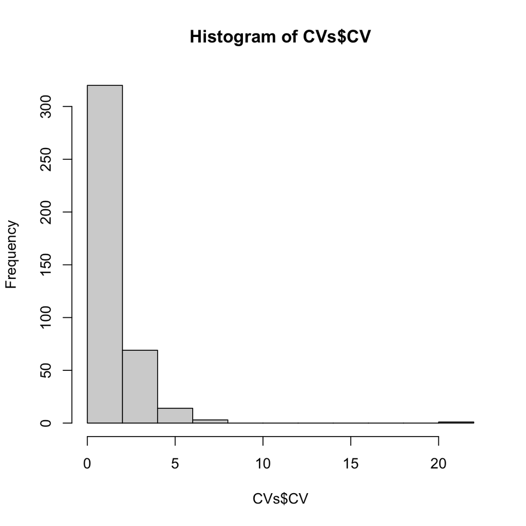

```r
hist(CVs$CV)
```

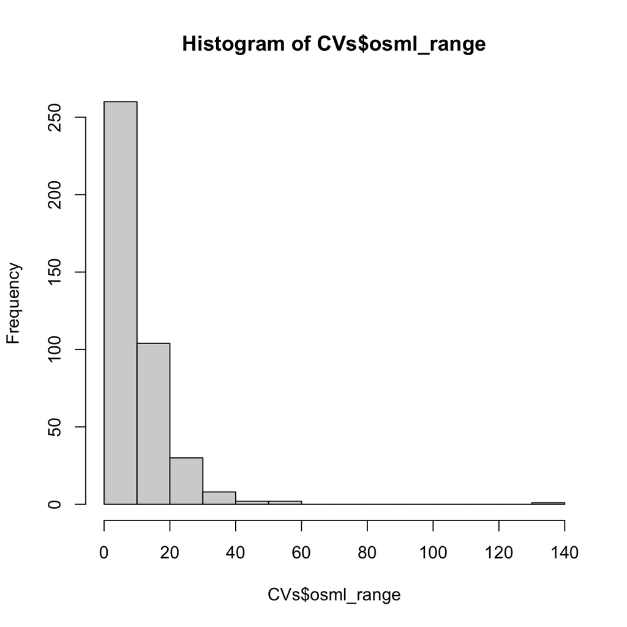

```r
hist(CVs$osml_range)
```

Ideally, CV would be <10-15%. If it’s larger, and one of the replicates is very different than the others, we can assume that the replicates that are closer together are more reliable.

The CV is >10 for only one lizard on one date, so our replicates are already likely to accurately represent the true value. We don’t want to lose accuracy by searching for precision, so we will only remove the one point driving the enormous CV value.

## Find & Remove Outlier

```r
CVs %>% dplyr::filter(CV > 10)
```

```
## # A tibble: 1 × 8
## # Groups:   individual_ID [1]
##   individual_ID date_blood_drawn  mean    SD    CV   min   max osml_range
##   <fct>         <date>           <dbl> <dbl> <dbl> <dbl> <dbl>      <dbl>
## 1 225           2021-06-26        325.  69.8  21.5   247   381        134
```

Determine which replicate of that group is an outlier and pulls the CV above our acceptable range (10-15%).

```r
enuf_reps %>%
  dplyr::filter(individual_ID == 225 & date_blood_drawn == "2021-06-26")
```

```
## # A tibble: 3 × 8
## # Groups:   individual_ID, date_blood_drawn [1]
##   date_bloo…¹ date_osm…² time_osmom_run      indiv…³ repli…⁴ osmol…⁵ notes count
##   <date>      <date>     <dttm>              <fct>   <fct>     <dbl> <lgl> <int>
## 1 2021-06-26  2021-06-26 2023-01-12 09:42:00 225     1           381 NA        3
## 2 2021-06-26  2021-06-26 2023-01-12 09:42:00 225     2           247 NA        3
## 3 2021-06-26  2021-06-26 2023-01-12 09:42:00 225     3           348 NA        3
## # … with abbreviated variable names ¹date_blood_drawn, ²date_osmom_run,
## #   ³individual_ID, ⁴replicate_no, ⁵osmolality_mmol_kg
```

We should remove replicate 2 for individual 225 on June 26, which is >100 mmol/kg away from the closest values, and the other two values are within 35 mmol/kg.

```r
enuf_reps_trimmed <- enuf_reps %>%
  # remove the one outlier
  dplyr::filter(!(individual_ID == 225 &
                  date_blood_drawn == "2021-06-26" &
                  replicate_no == 2))

# check
enuf_reps_trimmed %>%
  dplyr::filter(individual_ID == 225 &
                  date_blood_drawn == "2021-06-26")
```

```
## # A tibble: 2 × 8
## # Groups:   individual_ID, date_blood_drawn [1]
##   date_bloo…¹ date_osm…² time_osmom_run      indiv…³ repli…⁴ osmol…⁵ notes count
##   <date>      <date>     <dttm>              <fct>   <fct>     <dbl> <lgl> <int>
## 1 2021-06-26  2021-06-26 2023-01-12 09:42:00 225     1           381 NA        3
## 2 2021-06-26  2021-06-26 2023-01-12 09:42:00 225     3           348 NA        3
## # … with abbreviated variable names ¹date_blood_drawn, ²date_osmom_run,
## #   ³individual_ID, ⁴replicate_no, ⁵osmolality_mmol_kg
```

## Average Remaining Replicates

Now that the single outlier has been removed from the technical replicates when there were enough replicates to identify them, I will rejoin the data for lizards with 1-2 (not_reps) and 3-4 (enuf_reps) replicates, then average the technical replicates for each lizard on each of their measurement dates.

```r
osml_means <- not_reps %>%
  rbind(enuf_reps_trimmed) %>%
  group_by(date_blood_drawn, individual_ID) %>%
  summarise(osmolality_mmol_kg_mean = mean(osmolality_mmol_kg))
```

# Other Cleaning

10 lizards in trial 1 have unreasonably high osmolality measurements on June 24, which we think are due to an osmometer technical error, as they were all from the same time period. The values are way too far outside the usual range to be trustworthy, and these measurements were taken just before the osmometer had to be recalibrated, so we will exclude them.

```r
osml_means_clean <- osml_means %>%
  dplyr::filter(!(osmolality_mmol_kg_mean > 500))
```

# Export

```r
write_rds(osml_means_clean, "./data/osml_means_clean.RDS")
```

# Reporting

We only removed one measurement that was an outlier within its technical replicate group.

We omitted 10 mean measurements (after taking tech rep mean) for lizards in trial 1 which had unreasonably high osmolality measurements on June 24 that can be confidently attributed to intrumental error.